# mashable_SVM_and_LR_2017.10.05.18.30

## MSDS 7331 Data Mining: Regression & SVM

Team: Andrew Abbott, Vivek Bejugama, Patrick McDevitt, Preeti Swaminathan

We are using an online news popularity dataset from the UCI Machine Learning Repository. The dataset is a collection of 61 heterogeneous features for approximately 40,000 articles published by Mashable (www.mashable.com). The features are not the articles, but are extracted from the articles, such as word counts, title word counts, and keyword associations. The data represents a two year period of published articles, ending in January 2015.

We intend to mine this data to understand what parameters can influence an article to be shared on social media more than others. The goal is to predict the number of shares in social networks (popularity).

The business use of this data set / data mining project is ultimately to establish relationships that enable to predict how many social media shares an article published on *www.mashable.com* is likley to generate - with the idea that a more socially shared article has higher business value - increasing traffic to the site, and consequently, potential for higher earnings revenue associated to the increased web traffic. The user of this model is both the publishers for *mashable.com* for article selection, and also for authors, attempting to create content that has higher value on sites like *mashable.com*.

Measures for a successful outcome from a predictive model for this study will be based on overall accuracy metrics (e.g., confusion matrix), as well as AUC type metrics. A baseline (non-predictive, random) scoring will establish a baseline for these metrics, and then the predictive model can be assessed against a random model for measurement of improvement, i.e., value of the model.

The data is located at https://archive.ics.uci.edu/ml/datasets/Online+News+Popularity

**Citation Request** :

K. Fernandes, P. Vinagre and P. Cortez. A Proactive Intelligent Decision Support System for Predicting the Popularity of Online News. Proceedings of the 17th EPIA 2015 - Portuguese Conference on Artificial Intelligence, September, Coimbra, Portugal.

- The data set has features in these 6 broad categories :  
  *(ref - see citation reference at beginning of this document)*
  - Words
    - Number of words of the title/content
    - Average word length
    - Rate of unique/non-stop words of contents
  - Links
    - Number of links
    - Number of links to other articles in Mashable
  - Digital Media
    - Number of images/videos
  - Time
    - Day of the week/weekend
  - Keywords
    - Number of keywords
    - Worst/best/average keywords (#shares)
    - Article category
  - NLP
    - Closeness to five LDA topics
    - Title/Text polarity/subjectivity
    - Rate and polarity of positive/negative words
    - Absolute subjectivity/polarity level

### __Assignment Content

#### **Create Models**

- Create a logistic regression model and a support vector machine model for the classification task involved with your dataset.
- Assess how well each model performs (use 80/20 training/testing split for your data).
- Adjust parameters of the models to make them more accurate.
- If your dataset size requires the use of stochastic gradient descent, then linear kernel only is fine to use. That is, the SGDClassifier is fine to use for optimizing logistic regression and linear support vector machines.
- For many problems, SGD will be required in order to train the SVM model in a reasonable timeframe.
  - We did not use SGD in this SVM model; with the features that we inlcuded, the SVM model with either linear or radial basis function typically converged to a solution within a few minutes; processing times for various models are included in the details below

#### **Model Advantages**

- Discuss the advantages of each model for each classification task.
- Does one type of model offer superior performance over another in terms of prediction accuracy?
- In terms of training time or efficiency?
- Explain in detail.

#### **Interpret Feature Importance**

- Use the weights from logistic regression to interpret the importance of different features for the classification task.
- Explain your interpretation in detail.
- Why do you think some variables are more important?

#### **Interpret Support Vectors**

- Look at the chosen support vectors for the classification task.
- Do these provide any insight into the data? Explain.
- If you used stochastic gradient descent (and therefore did not explicitly solve for support vectors), try subsampling your data to train the SVC model — then analyze the support vectors from the subsampled dataset.
  - We did not use SGD in this SVM model

The analyses inlcuded here for the SVM and Logistic Regression relied on the templates provided by Dr Larsen and modified / expanded here to suit this particular problem set. Dr Larsen's original templates can be found at this github repository : https://github.com/eclarson/DataMiningNotebooks/blob/master/04.%20Logits%20and%20SVM.ipynb

### Data Loading and cleanup

#### Import Required Packages

```python
import pandas as pd
import numpy as np
import matplotlib.pyplot as plt
%matplotlib inline
import warnings
warnings.simplefilter('ignore',DeprecationWarning)
import seaborn as sns
import time
```

#### Import Data from .csv file

```python
data_dir = 'C:/Users/Preeti/data/'
data_file = 'OnlineNewsPopularity.csv'

file_2_read = data_dir + data_file
df = pd.read_csv(file_2_read)
```

#### Strip leading spaces from column names

```python
df.columns = df.columns.str.strip()
col_names = df.columns.values.tolist()
```

An initial summary of the dataset attribute follows along with the simple statistics of the numeric attributes.

```python
#df.info()
```

```python
df.describe().T
```

|  | count | mean | std | min | 25% | 50% | 75% | max |
| --- | --- | --- | --- | --- | --- | --- | --- | --- |
| timedelta | 39644.0 | 354.530471 | 214.163767 | 8.00000 | 164.000000 | 339.000000 | 542.000000 | 731.000000 |
| n_tokens_title | 39644.0 | 10.398749 | 2.114037 | 2.00000 | 9.000000 | 10.000000 | 12.000000 | 23.000000 |
| n_tokens_content | 39644.0 | 546.514731 | 471.107508 | 0.00000 | 246.000000 | 409.000000 | 716.000000 | 8474.000000 |
| n_unique_tokens | 39644.0 | 0.548216 | 3.520708 | 0.00000 | 0.470870 | 0.539226 | 0.608696 | 701.000000 |
| n_non_stop_words | 39644.0 | 0.996469 | 5.231231 | 0.00000 | 1.000000 | 1.000000 | 1.000000 | 1042.000000 |
| n_non_stop_unique_tokens | 39644.0 | 0.689175 | 3.264816 | 0.00000 | 0.625739 | 0.690476 | 0.754630 | 650.000000 |
| num_hrefs | 39644.0 | 10.883690 | 11.332017 | 0.00000 | 4.000000 | 8.000000 | 14.000000 | 304.000000 |
| num_self_hrefs | 39644.0 | 3.293638 | 3.855141 | 0.00000 | 1.000000 | 3.000000 | 4.000000 | 116.000000 |
| num_imgs | 39644.0 | 4.544143 | 8.309434 | 0.00000 | 1.000000 | 1.000000 | 4.000000 | 128.000000 |
| num_videos | 39644.0 | 1.249874 | 4.107855 | 0.00000 | 0.000000 | 0.000000 | 1.000000 | 91.000000 |
| average_token_length | 39644.0 | 4.548239 | 0.844406 | 0.00000 | 4.478404 | 4.664082 | 4.854839 | 8.041534 |
| num_keywords | 39644.0 | 7.223767 | 1.909130 | 1.00000 | 6.000000 | 7.000000 | 9.000000 | 10.000000 |
| data_channel_is_lifestyle | 39644.0 | 0.052946 | 0.223929 | 0.00000 | 0.000000 | 0.000000 | 0.000000 | 1.000000 |
| data_channel_is_entertainment | 39644.0 | 0.178009 | 0.382525 | 0.00000 | 0.000000 | 0.000000 | 0.000000 | 1.000000 |
| data_channel_is_bus | 39644.0 | 0.157855 | 0.364610 | 0.00000 | 0.000000 | 0.000000 | 0.000000 | 1.000000 |
| data_channel_is_socmed | 39644.0 | 0.058597 | 0.234871 | 0.00000 | 0.000000 | 0.000000 | 0.000000 | 1.000000 |
| data_channel_is_tech | 39644.0 | 0.185299 | 0.388545 | 0.00000 | 0.000000 | 0.000000 | 0.000000 | 1.000000 |
| data_channel_is_world | 39644.0 | 0.212567 | 0.409129 | 0.00000 | 0.000000 | 0.000000 | 0.000000 | 1.000000 |
| kw_min_min | 39644.0 | 26.106801 | 69.633215 | -1.00000 | -1.000000 | -1.000000 | 4.000000 | 377.000000 |
| kw_max_min | 39644.0 | 1153.951682 | 3857.990877 | 0.00000 | 445.000000 | 660.000000 | 1000.000000 | 298400.000000 |
| kw_avg_min | 39644.0 | 312.366967 | 620.783887 | -1.00000 | 141.750000 | 235.500000 | 357.000000 | 42827.857140 |
| kw_min_max | 39644.0 | 13612.354102 | 57986.029357 | 0.00000 | 0.000000 | 1400.000000 | 7900.000000 | 843300.000000 |
| kw_max_max | 39644.0 | 752324.066694 | 214502.129573 | 0.00000 | 843300.000000 | 843300.000000 | 843300.000000 | 843300.000000 |
| kw_avg_max | 39644.0 | 259281.938083 | 135102.247285 | 0.00000 | 172846.875000 | 244572.222250 | 330980.000000 | 843300.000000 |
| kw_min_avg | 39644.0 | 1117.146610 | 1137.456951 | -1.00000 | 0.000000 | 1023.635611 | 2056.781031 | 3613.039820 |
| kw_max_avg | 39644.0 | 5657.211151 | 6098.871957 | 0.00000 | 3562.101631 | 4355.688836 | 6019.953968 | 298400.000000 |
| kw_avg_avg | 39644.0 | 3135.858639 | 1318.150397 | 0.00000 | 2382.448565 | 2870.074878 | 3600.229564 | 43567.659950 |
| self_reference_min_shares | 39644.0 | 3998.755396 | 19738.670516 | 0.00000 | 639.000000 | 1200.000000 | 2600.000000 | 843300.000000 |
| self_reference_max_shares | 39644.0 | 10329.212662 | 41027.576613 | 0.00000 | 1100.000000 | 2800.000000 | 8000.000000 | 843300.000000 |
| self_reference_avg_sharess | 39644.0 | 6401.697580 | 24211.332231 | 0.00000 | 981.187500 | 2200.000000 | 5200.000000 | 843300.000000 |
| weekday_is_monday | 39644.0 | 0.168020 | 0.373889 | 0.00000 | 0.000000 | 0.000000 | 0.000000 | 1.000000 |
| weekday_is_tuesday | 39644.0 | 0.186409 | 0.389441 | 0.00000 | 0.000000 | 0.000000 | 0.000000 | 1.000000 |
| weekday_is_wednesday | 39644.0 | 0.187544 | 0.390353 | 0.00000 | 0.000000 | 0.000000 | 0.000000 | 1.000000 |
| weekday_is_thursday | 39644.0 | 0.183306 | 0.386922 | 0.00000 | 0.000000 | 0.000000 | 0.000000 | 1.000000 |
| weekday_is_friday | 39644.0 | 0.143805 | 0.350896 | 0.00000 | 0.000000 | 0.000000 | 0.000000 | 1.000000 |
| weekday_is_saturday | 39644.0 | 0.061876 | 0.240933 | 0.00000 | 0.000000 | 0.000000 | 0.000000 | 1.000000 |
| weekday_is_sunday | 39644.0 | 0.069039 | 0.253524 | 0.00000 | 0.000000 | 0.000000 | 0.000000 | 1.000000 |
| is_weekend | 39644.0 | 0.130915 | 0.337312 | 0.00000 | 0.000000 | 0.000000 | 0.000000 | 1.000000 |
| LDA_00 | 39644.0 | 0.184599 | 0.262975 | 0.00000 | 0.025051 | 0.033387 | 0.240958 | 0.926994 |
| LDA_01 | 39644.0 | 0.141256 | 0.219707 | 0.00000 | 0.025012 | 0.033345 | 0.150831 | 0.925947 |
| LDA_02 | 39644.0 | 0.216321 | 0.282145 | 0.00000 | 0.028571 | 0.040004 | 0.334218 | 0.919999 |
| LDA_03 | 39644.0 | 0.223770 | 0.295191 | 0.00000 | 0.028571 | 0.040001 | 0.375763 | 0.926534 |
| LDA_04 | 39644.0 | 0.234029 | 0.289183 | 0.00000 | 0.028574 | 0.040727 | 0.399986 | 0.927191 |
| global_subjectivity | 39644.0 | 0.443370 | 0.116685 | 0.00000 | 0.396167 | 0.453457 | 0.508333 | 1.000000 |
| global_sentiment_polarity | 39644.0 | 0.119309 | 0.096931 | -0.39375 | 0.057757 | 0.119117 | 0.177832 | 0.727841 |
| global_rate_positive_words | 39644.0 | 0.039625 | 0.017429 | 0.00000 | 0.028384 | 0.039023 | 0.050279 | 0.155488 |
| global_rate_negative_words | 39644.0 | 0.016612 | 0.010828 | 0.00000 | 0.009615 | 0.015337 | 0.021739 | 0.184932 |
| rate_positive_words | 39644.0 | 0.682150 | 0.190206 | 0.00000 | 0.600000 | 0.710526 | 0.800000 | 1.000000 |
| rate_negative_words | 39644.0 | 0.287934 | 0.156156 | 0.00000 | 0.185185 | 0.280000 | 0.384615 | 1.000000 |
| avg_positive_polarity | 39644.0 | 0.353825 | 0.104542 | 0.00000 | 0.306244 | 0.358755 | 0.411428 | 1.000000 |
| min_positive_polarity | 39644.0 | 0.095446 | 0.071315 | 0.00000 | 0.050000 | 0.100000 | 0.100000 | 1.000000 |
| max_positive_polarity | 39644.0 | 0.756728 | 0.247786 | 0.00000 | 0.600000 | 0.800000 | 1.000000 | 1.000000 |
| avg_negative_polarity | 39644.0 | -0.259524 | 0.127726 | -1.00000 | -0.328383 | -0.253333 | -0.186905 | 0.000000 |
| min_negative_polarity | 39644.0 | -0.521944 | 0.290290 | -1.00000 | -0.700000 | -0.500000 | -0.300000 | 0.000000 |
| max_negative_polarity | 39644.0 | -0.107500 | 0.095373 | -1.00000 | -0.125000 | -0.100000 | -0.050000 | 0.000000 |
| title_subjectivity | 39644.0 | 0.282353 | 0.324247 | 0.00000 | 0.000000 | 0.150000 | 0.500000 | 1.000000 |
| title_sentiment_polarity | 39644.0 | 0.071425 | 0.265450 | -1.00000 | 0.000000 | 0.000000 | 0.150000 | 1.000000 |
| abs_title_subjectivity | 39644.0 | 0.341843 | 0.188791 | 0.00000 | 0.166667 | 0.500000 | 0.500000 | 0.500000 |
| abs_title_sentiment_polarity | 39644.0 | 0.156064 | 0.226294 | 0.00000 | 0.000000 | 0.000000 | 0.250000 | 1.000000 |
| shares | 39644.0 | 3395.380184 | 11626.950749 | 1.00000 | 946.000000 | 1400.000000 | 2800.000000 | 843300.000000 |

```python
del df['n_non_stop_words']
del df['n_non_stop_unique_tokens']
del df['n_unique_tokens']
```

The next step is to convert the attributes to their appropriate data types.

```python
# ... -=-=-=-=-=-=-=-=-=-=-=-=-=-=-=-=-=-=-=-=-=-=-=-=-=-=-=-=-=-=-=-=-=-=-=-=-=
# ...  convert the data type to Integer
# ... -=-=-=-=-=-=-=-=-=-=-=-=-=-=-=-=-=-=-=-=-=-=-=-=-=-=-=-=-=-=-=-=-=-=-=-=-=

to_int = ['timedelta','n_tokens_title', 'n_tokens_content',
    'num_hrefs','num_self_hrefs', 'num_imgs', 'num_videos', 'num_keywords',
    'data_channel_is_lifestyle',
    'data_channel_is_entertainment',
    'data_channel_is_bus',
    'data_channel_is_socmed',
    'data_channel_is_tech',
    'data_channel_is_world',
    'weekday_is_monday',
    'weekday_is_tuesday',
    'weekday_is_wednesday',
    'weekday_is_thursday',
    'weekday_is_friday',
    'weekday_is_saturday',
    'weekday_is_sunday',
    'is_weekend',
    'shares']

df[to_int] = df[to_int ].astype(np.int64)
```

Now a check for duplicates is done to ensure that the data set does not contain duplicated observations. No Duplicates are found.

```python
df[df.duplicated()]
```

|  | url | timedelta | n_tokens_title | n_tokens_content | num_hrefs | num_self_hrefs | num_imgs | num_videos | average_token_length | num_keywords | ... | min_positive_polarity | max_positive_polarity | avg_negative_polarity | min_negative_polarity | max_negative_polarity | title_subjectivity | title_sentiment_polarity | abs_title_subjectivity | abs_title_sentiment_polarity | shares |
| --- | --- | --- | --- | --- | --- | --- | --- | --- | --- | --- | --- | --- | --- | --- | --- | --- | --- | --- | --- | --- | --- |

0 rows × 58 columns

#### Create new features from existing data set

- Based on inspection of the data set, we identified several opportunities to create some useful features from the original data set.
- The first data field, *url*, is the url address of the mashable published article, which contains in the link the year, month, day that the article was published and also the article title. We will use a string splitting function to parse the information in the url address to create the additional data columns : *year*, *month*, *day*, and *title*. Further, we can then combine the parsed year, month, day into a _published*date* column. Although the original data set does contain the field *timedelta* which provdes essentially a timeline of article publication dates, it does not contain the actual date of publication. We consider that having the actual date may prove useful to provide context or linkage with external data sources. We are not, at this time, linking in any additional external data sources, but that may be an opportunity with future work. In addition, we consider to storethe *title* as a distinct data column, but we are not performing any analysis on that field at this time. We consider that the article title is an opportunity for text mining in the classification problem to be evaluated also with future work.
- We check the skewness of the numeric attributes and transform those with extreme skew using a log transformation. The original, non-transformed attribute is then removed from the analysis.
- We also created a column to be used as binary popularity measure. Based on the business description of the goal, the goal is to build a model that provides predictive capability of article 'popular' or 'not popular', based on the metric of number of shares > 1400 (popular) or number of shares < 1400 (not popular). The value of 1400 was provided in the business statement, and is also the median value of the number of shares in the experience of this data set. To accomplish that purpose, we create a new column (binary) *popularity* which is based on the number of shares reported in the *shares* data column. This can be used in future work, e.g., in classificiation or binary logistic regression analyses to support the business goal.
- The code to accomplish all of the above is shown here below.

```python
# ... -=-=-=-=-=-=-=-=-=-=-=-=-=-=-=-=-=-=-=-=-=-=-=-=-=-=-=-=-=-=-=-=-=-=-=-=-=
# ... Extract useable elements from the string URL
# ... -=-=-=-=-=-=-=-=-=-=-=-=-=-=-=-=-=-=-=-=-=-=-=-=-=-=-=-=-=-=-=-=-=-=-=-=-=

df['http'], df['blank'], df['mash'], df['year'], df['month'], df['day'],df['title'],df['extra'] = df['url'].str.split('\/', 7).str

# ...  delete unneeded columns

del df['http'], df['blank'], df['mash'], df['extra']
del df['url']
del df['title']

# ... -=-=-=-=-=-=-=-=-=-=-=-=-=-=-=-=-=-=-=-=-=-=-=-=-=-=-=-=-=-=-=-=-=-=-=-=-=
# ...  Derive date column from year-month-day fields
# ... -=-=-=-=-=-=-=-=-=-=-=-=-=-=-=-=-=-=-=-=-=-=-=-=-=-=-=-=-=-=-=-=-=-=-=-=-=

df['year']  = (df['year']).astype(str)
df['month'] = (df['month']).astype(str)
df['day']   = (df['day']).astype(str)
df['publish_date'] = pd.to_datetime(df.year + df.month + df.day, format = "%Y%m%d")

del df['month']
del df['day']

df['year'] = df['year'].astype(int)

del df['publish_date']
```

```python
# ... -=-=-=-=-=-=-=-=-=-=-=-=-=-=-=-=-=-=-=-=-=-=-=-=-=-=-=-=-=-=-=-=-=-=-=-=-=
# ...  ln() transform right skewed distribution variables (skewness > 1)
# ... -=-=-=-=-=-=-=-=-=-=-=-=-=-=-=-=-=-=-=-=-=-=-=-=-=-=-=-=-=-=-=-=-=-=-=-=-=

df_numeric = df.select_dtypes(['number'])

numeric_col_names = df_numeric.columns.values.tolist()

# ... store min value for each column

df_mins = df.min()

# ... -=-=-=-=-=-=-=-=-=-=-=-=-=-=-=-=-=-=-=-=-=-=-=-=-=-=-=-=-=-=-=-=-=-=-=-=-=
# ...  loop on each column, test for skewness, create new column if conditions met
# ... -=-=-=-=-=-=-=-=-=-=-=-=-=-=-=-=-=-=-=-=-=-=-=-=-=-=-=-=-=-=-=-=-=-=-=-=-=

columns_to_drop = []

for column in numeric_col_names:
    sk = df[column].skew()

    if(sk > 1):
        new_col_name = 'ln_' + column
        print (column, sk, new_col_name)

        if df_mins[column] > 0:
            df[new_col_name] = np.log(df[column])
            columns_to_drop.append(column)

        elif df_mins[column] == 0:
            df_tmp = df[column] + 1
            df[new_col_name] = np.log(df_tmp)
            columns_to_drop.append(column)

        else:
            print('--> Ln() transform not completed -- skew > 1, but min value < 0 :', column, '!!')


# ... delete tmp data

del df_tmp
del df_mins
del df_numeric

# ... -=-=-=-=-=-=-=-=-=-=-=-=-=-=-=-=-=-=-=-=-=-=-=-=-=-=-=-=-=-=-=-=-=-=-=-=-=
# ...  based on inspection, a few of these are just not valid ranges in ln() space
# ...  -- just delete these few back out of the data set
# ... -=-=-=-=-=-=-=-=-=-=-=-=-=-=-=-=-=-=-=-=-=-=-=-=-=-=-=-=-=-=-=-=-=-=-=-=-=

print (columns_to_drop)



del df['ln_LDA_00']
del df['ln_LDA_01']
del df['ln_LDA_02']
del df['ln_LDA_03']
del df['ln_LDA_04']
columns_to_drop.remove('LDA_00')
columns_to_drop.remove('LDA_01')
columns_to_drop.remove('LDA_02')
columns_to_drop.remove('LDA_03')
columns_to_drop.remove('LDA_04')


# ...  these are binary indicators ... so no need to ln-transform

del df['ln_data_channel_is_lifestyle']
del df['ln_data_channel_is_entertainment']
del df['ln_data_channel_is_bus']
del df['ln_data_channel_is_socmed']
del df['ln_data_channel_is_tech']
del df['ln_data_channel_is_world']
del df['ln_weekday_is_monday']
del df['ln_weekday_is_tuesday']
del df['ln_weekday_is_wednesday']
del df['ln_weekday_is_thursday']
del df['ln_weekday_is_friday']
del df['ln_weekday_is_saturday']
del df['ln_weekday_is_sunday']

del df['ln_is_weekend']
columns_to_drop.remove('is_weekend')

columns_to_drop.remove('data_channel_is_lifestyle')
columns_to_drop.remove('data_channel_is_entertainment')
columns_to_drop.remove('data_channel_is_bus')
columns_to_drop.remove('data_channel_is_socmed')
columns_to_drop.remove('data_channel_is_tech')
columns_to_drop.remove('data_channel_is_world')
columns_to_drop.remove('weekday_is_monday')
columns_to_drop.remove('weekday_is_tuesday')
columns_to_drop.remove('weekday_is_wednesday')
columns_to_drop.remove('weekday_is_thursday')
columns_to_drop.remove('weekday_is_friday')
columns_to_drop.remove('weekday_is_saturday')
columns_to_drop.remove('weekday_is_sunday')


# ... not needed for binary analysis ... will use popular indicator

del df['ln_shares']
columns_to_drop.remove('shares')

print ('\n-----------------------------------\n')
print ('Number of current columns in dataset :', len(df.columns))



df.drop(columns_to_drop, axis = 1, inplace = True)

#df.info()
```

```
n_tokens_content 2.94542193879 ln_n_tokens_content
num_hrefs 4.0134948282 ln_num_hrefs
num_self_hrefs 5.17275110576 ln_num_self_hrefs
num_imgs 3.94659584465 ln_num_imgs
num_videos 7.0195327863 ln_num_videos
data_channel_is_lifestyle 3.99301914336 ln_data_channel_is_lifestyle
data_channel_is_entertainment 1.6835848094 ln_data_channel_is_entertainment
data_channel_is_bus 1.87687018599 ln_data_channel_is_bus
data_channel_is_socmed 3.75887963097 ln_data_channel_is_socmed
data_channel_is_tech 1.61997576469 ln_data_channel_is_tech
data_channel_is_world 1.40516938412 ln_data_channel_is_world
kw_min_min 2.37494728018 ln_kw_min_min
--> Ln() transform not completed -- skew > 1, but min value < 0 : kw_min_min !!
kw_max_min 35.3284337312 ln_kw_max_min
kw_avg_min 31.3061081021 ln_kw_avg_min
--> Ln() transform not completed -- skew > 1, but min value < 0 : kw_avg_min !!
kw_min_max 10.3863716348 ln_kw_min_max
kw_max_avg 16.4116695557 ln_kw_max_avg
kw_avg_avg 5.76017729205 ln_kw_avg_avg
self_reference_min_shares 26.2643641603 ln_self_reference_min_shares
self_reference_max_shares 13.8708490494 ln_self_reference_max_shares
self_reference_avg_sharess 17.9140933777 ln_self_reference_avg_sharess
weekday_is_monday 1.77590824423 ln_weekday_is_monday
weekday_is_tuesday 1.61054706191 ln_weekday_is_tuesday
weekday_is_wednesday 1.60097097689 ln_weekday_is_wednesday
weekday_is_thursday 1.6370700483 ln_weekday_is_thursday
weekday_is_friday 2.03030483518 ln_weekday_is_friday
weekday_is_saturday 3.63708575997 ln_weekday_is_saturday
weekday_is_sunday 3.3999273763 ln_weekday_is_sunday
is_weekend 2.18850033431 ln_is_weekend
LDA_00 1.56746323321 ln_LDA_00
LDA_01 2.0867218234 ln_LDA_01
LDA_02 1.31169490202 ln_LDA_02
LDA_03 1.23871598638 ln_LDA_03
LDA_04 1.17312947598 ln_LDA_04
global_rate_negative_words 1.49191730953 ln_global_rate_negative_words
min_positive_polarity 3.04046773447 ln_min_positive_polarity
abs_title_sentiment_polarity 1.70419344006 ln_abs_title_sentiment_polarity
shares 33.9638848757 ln_shares
['n_tokens_content', 'num_hrefs', 'num_self_hrefs', 'num_imgs', 'num_videos', 'data_channel_is_lifestyle', 'data_channel_is_entertainment', 'data_channel_is_bus', 'data_channel_is_socmed', 'data_channel_is_tech', 'data_channel_is_world', 'kw_max_min', 'kw_min_max', 'kw_max_avg', 'kw_avg_avg', 'self_…

-----------------------------------

Number of current columns in dataset : 73
```

#### Data Selection - First evaluation

- There are 60 columns in the original data set; we added a few additonal columns based on observed opportunities (e.g., _publication*date*, ...) as explained above.
- From this data set, we did a simple correlation matrix to look for variables that are highly correlated with each other that could be removed with little loss of information.
- With that downselection, we proceeded with additional evaluation of these remaining variables.
- we recognize that there is likely significant additional opportunity for modeling improvements with many of the remaining variables, and will look to re-expand the data set to further consider that with future work.

```python
# ... -=-=-=-=-=-=-=-=-=-=-=-=-=-=-=-=-=-=-=-=-=-=-=-=-=-=-=-=-=-=-=-=-=-=-=-=-=
# ... display highest correlation pairs from corr() matrix
# ...
# ... https://stackoverflow.com/questions/17778394/list-highest-correlation-pairs-from-a-large-correlation-matrix-in-pandas
# ... -=-=-=-=-=-=-=-=-=-=-=-=-=-=-=-=-=-=-=-=-=-=-=-=-=-=-=-=-=-=-=-=-=-=-=-=-=

df_numeric = df.select_dtypes(['number'])

def get_redundant_pairs(df):
    '''Get diagonal and lower triangular pairs of correlation matrix'''
    pairs_to_drop = set()
    cols = df.columns
    for i in range(0, df.shape[1]):
        for j in range(0, i+1):
            pairs_to_drop.add((cols[i], cols[j]))
    return pairs_to_drop

def get_top_abs_correlations(df, n = 5):
    au_corr = df.corr().abs().unstack()
    labels_to_drop = get_redundant_pairs(df)
    au_corr = au_corr.drop(labels = labels_to_drop).sort_values(ascending = False)
    return au_corr[0:n]

# ... -=-=-=-=-=-=-=-=-=-=-=-=-=-=-=-=-=-=-=-=-=-=-=-=-=-=-=-=-=-=-=-=-=-=-=-=-=
# ... list out Top30 correlations
# ... -=-=-=-=-=-=-=-=-=-=-=-=-=-=-=-=-=-=-=-=-=-=-=-=-=-=-=-=-=-=-=-=-=-=-=-=-=

n_val = 30

top_30_corr_list = get_top_abs_correlations(df_numeric, n_val)
print("\n\n-=-=-=-=-=-=-=-=-=-=-=-=-=-=-=-=-=-=-=-=-=-=-=-=-=-=-=-=-")
print("Top Absolute Correlations\n")
print(top_30_corr_list)

icor = 0
drop_column = list()
while (top_30_corr_list[icor] > 0.65):
    drop_column.append(top_30_corr_list[top_30_corr_list == top_30_corr_list[icor]].index[0][0])
    icor += 1

drop_column = list(set(drop_column))

print("\n\n-=-=-=-=-=-=-=-=-=-=-=-=-=-=-=-=-=-=-=-=-=-=-=-=-=-=-=-=-")
print("Columns Recommended for removal based on correlation > 0.65")
print("-=-=-=-=-=-=-=-=-=-=-=-=-=-=-=-=-=-=-=-=-=-=-=-=-=-=-=-=-\n")

print("\n".join(sorted(drop_column)))

# ... -=-=-=-=-=-=-=-=-=-=-=-=-=-=-=-=-=-=-=-=-=-=-=-=-=-=-=-=-=-=-=-=-=-=-=-=-=
# ... drop one of the high correlation columns (2nd of the pair)
# ... -=-=-=-=-=-=-=-=-=-=-=-=-=-=-=-=-=-=-=-=-=-=-=-=-=-=-=-=-=-=-=-=-=-=-=-=-=

df = df.drop(drop_column, axis = 1)

# ... -=-=-=-=-=-=-=-=-=-=-=-=-=-=-=-=-=-=-=-=-=-=-=-=-=-=-=-=-=-=-=-=-=-=-=-=-=
# ... show correlation test with remaining, to confirm
# ... -=-=-=-=-=-=-=-=-=-=-=-=-=-=-=-=-=-=-=-=-=-=-=-=-=-=-=-=-=-=-=-=-=-=-=-=-=

df_reduced_numeric = df.select_dtypes(['number'])

top_30_corr_list = get_top_abs_correlations(df_reduced_numeric, n_val)

print("\n\n-=-=-=-=-=-=-=-=-=-=-=-=-=-=-=-=-=-=-=-=-=-=-=-=-=-=-=-=-")
print("\n\nTop Absolute Correlations (2nd Pass)\n")
print(top_30_corr_list)
```

```
-=-=-=-=-=-=-=-=-=-=-=-=-=-=-=-=-=-=-=-=-=-=-=-=-=-=-=-=-
Top Absolute Correlations

ln_self_reference_max_shares   ln_self_reference_avg_sharess      0.994639
ln_self_reference_min_shares   ln_self_reference_avg_sharess      0.971014
                               ln_self_reference_max_shares       0.945943
kw_min_avg                     ln_kw_min_max                      0.926784
ln_kw_max_avg                  ln_kw_avg_avg                      0.899409
timedelta                      year                               0.876403
kw_min_min                     kw_max_max                         0.857226
data_channel_is_world          LDA_02                             0.836618
rate_negative_words            ln_global_rate_negative_words      0.782517
data_channel_is_bus            LDA_00                             0.774651
average_token_length           ln_n_tokens_content                0.768795
data_channel_is_tech           LDA_04                             0.749737
avg_negative_polarity          min_negative_polarity              0.748896
title_subjectivity             ln_abs_title_sentiment_polarity    0.741229
global_sentiment_polarity      rate_positive_words                0.727827
avg_positive_polarity          max_positive_polarity              0.703558
weekday_is_sunday              is_weekend                         0.701648
ln_num_self_hrefs              ln_self_reference_max_shares       0.675339
weekday_is_saturday            is_weekend                         0.661707
global_sentiment_polarity      rate_negative_words                0.650717
max_positive_polarity          ln_n_tokens_content                0.643190
timedelta                      kw_max_max                         0.637824
ln_num_self_hrefs              ln_self_reference_avg_sharess      0.631820
global_subjectivity            avg_positive_polarity              0.631749
global_rate_positive_words     rate_positive_words                0.628626
ln_n_tokens_content            ln_num_hrefs                       0.614357
data_channel_is_entertainment  LDA_01                             0.599384
average_token_length           global_subjectivity                0.597629
timedelta                      kw_min_min                         0.591199
avg_negative_polarity          max_negative_polarity              0.580108
dtype: float64


-=-=-=-=-=-=-=-=-=-=-=-=-=-=-=-=-=-=-=-=-=-=-=-=-=-=-=-=-
Columns Recommended for removal based on correlation > 0.65
-=-=-=-=-=-=-=-=-=-=-=-=-=-=-=-=-=-=-=-=-=-=-=-=-=-=-=-=-

```

[output cut: 41 more lines]

```
max_positive_polarity          ln_num_hrefs                       0.450754
kw_avg_max                     ln_kw_avg_avg                      0.408879
title_sentiment_polarity       ln_abs_title_sentiment_polarity    0.406593
rate_positive_words            ln_global_rate_negative_words      0.398124
kw_avg_min                     ln_kw_max_min                      0.395837
kw_avg_max                     year                               0.394391
global_subjectivity            ln_num_hrefs                       0.387289
kw_avg_max                     ln_kw_min_max                      0.372577
max_positive_polarity          min_negative_polarity              0.360871
LDA_03                         LDA_04                             0.357930
min_negative_polarity          ln_num_hrefs                       0.354125
global_subjectivity            min_negative_polarity              0.350070
ln_num_hrefs                   ln_num_imgs                        0.347361
LDA_03                         ln_kw_avg_avg                      0.341938
dtype: float64
```

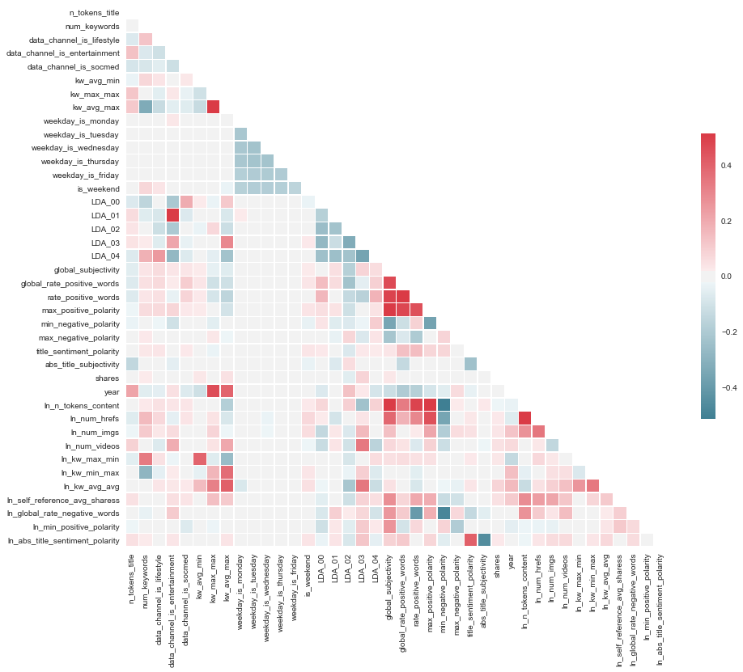

```python
sns.set(style="white")

# Compute the correlation matrix
corr = df.corr()

# Generate a mask for the upper triangle
mask = np.zeros_like(corr, dtype=np.bool)
mask[np.triu_indices_from(mask)] = True

# Set up the matplotlib figure
f, ax = plt.subplots(figsize=(15, 13))

# Generate a custom diverging colormap
cmap = sns.diverging_palette(220, 10, as_cmap=True)

# Draw the heatmap with the mask and correct aspect ratio
sns.heatmap(corr, mask=mask, cmap=cmap, vmax=.3, center=0,
            square=True, linewidths=.5, cbar_kws={"shrink": .5})


# from example found at https://www.kaggle.com/maheshdadhich/strength-of-visualization-python-visuals-tutorial/notebook
```

Popularity Variable is created. An article is labelled as popular if it has greater than 1,400 shares.

```python
popular_binary = np.where(df['shares'] > 1400, True, False)

df.insert(loc = 0, column = 'popular', value = popular_binary)

del df['shares']
```

```python
# ... -=-=-=-=-=-=-=-=-=-=-=-=-=-=-=-=-=-=-=-=-=-=-=-=-=-=-=-=-=-=-=-=-=-=-=-=-=
# ...  branch a separate copy of data frame to support SVM development
# ... -=-=-=-=-=-=-=-=-=-=-=-=-=-=-=-=-=-=-=-=-=-=-=-=-=-=-=-=-=-=-=-=-=-=-=-=-=

df_svm = df.copy()


data_dir = 'C:/Users/Preeti/data/'
data_file = 'mashable_clean_dataset_for_LR_and_SVM.csv'

file_2_write = data_dir + data_file

df_svm.to_csv(file_2_write, index = False)

df_svm.info()
```

```
<class 'pandas.core.frame.DataFrame'>
RangeIndex: 39644 entries, 0 to 39643
Data columns (total 40 columns):
popular                            39644 non-null bool
n_tokens_title                     39644 non-null int64
num_keywords                       39644 non-null int64
data_channel_is_lifestyle          39644 non-null int64
data_channel_is_entertainment      39644 non-null int64
data_channel_is_socmed             39644 non-null int64
kw_avg_min                         39644 non-null float64
kw_max_max                         39644 non-null int64
kw_avg_max                         39644 non-null float64
weekday_is_monday                  39644 non-null int64
weekday_is_tuesday                 39644 non-null int64
weekday_is_wednesday               39644 non-null int64
weekday_is_thursday                39644 non-null int64
weekday_is_friday                  39644 non-null int64
is_weekend                         39644 non-null int64
LDA_00                             39644 non-null float64
LDA_01                             39644 non-null float64
LDA_02                             39644 non-null float64
LDA_03                             39644 non-null float64
LDA_04                             39644 non-null float64
global_subjectivity                39644 non-null float64
global_rate_positive_words         39644 non-null float64
rate_positive_words                39644 non-null float64
max_positive_polarity              39644 non-null float64
min_negative_polarity              39644 non-null float64
max_negative_polarity              39644 non-null float64
title_sentiment_polarity           39644 non-null float64
abs_title_subjectivity             39644 non-null float64
year                               39644 non-null int32
ln_n_tokens_content                39644 non-null float64
ln_num_hrefs                       39644 non-null float64
ln_num_imgs                        39644 non-null float64
ln_num_videos                      39644 non-null float64
ln_kw_max_min                      39644 non-null float64
ln_kw_min_max                      39644 non-null float64
ln_kw_avg_avg                      39644 non-null float64
ln_self_reference_avg_sharess      39644 non-null float64
ln_global_rate_negative_words      39644 non-null float64
ln_min_positive_polarity           39644 non-null float64
ln_abs_title_sentiment_polarity    39644 non-null float64
dtypes: bool(1), float64(26), int32(1), int64(12)
memory usage: 11.7 MB
```

# Model Creation

## Training and Testing Split

```python
from sklearn.model_selection import ShuffleSplit
from sklearn.preprocessing import StandardScaler
from sklearn import metrics as mt
from sklearn.svm import SVC

df_svm_top39 = df_svm.copy()

# ... -=-=-=-=-=-=-=-=-=-=-=-=-=-=-=-=-=-=-=-=-=-=-=-=-=-=-=-=-=-=-=-=-=-=-=-=-=
# ...  dataframe in which to record results of model metrics
# ... -=-=-=-=-=-=-=-=-=-=-=-=-=-=-=-=-=-=-=-=-=-=-=-=-=-=-=-=-=-=-=-=-=-=-=-=-=

results_table_labels = ['kernel', 'C', 'gamma', 'n_features', 'process_time', 'accuracy', 'recall', 'precision', 'f1_score']
df_results = pd.DataFrame(columns = results_table_labels)

# ... -=-=-=-=-=-=-=-=-=-=-=-=-=-=-=-=-=-=-=-=-=-=-=-=-=-=-=-=-=-=-=-=-=-=-=-=-=
# ...  separate X and y matrices
# ...
# ...  convert to numpy matrices by calling 'values' on the pandas data frames
# ...  they are now simple matrices for compatibility with scikit-learn
# ... -=-=-=-=-=-=-=-=-=-=-=-=-=-=-=-=-=-=-=-=-=-=-=-=-=-=-=-=-=-=-=-=-=-=-=-=-=

if 'popular' in df_svm_top39:
    y = df_svm_top39['popular'].values         # set 'popular' as dependent
    del df_svm_top39['popular']                # remove from dataset
    X = df_svm_top39.values                    # use everything else for independent EVs

# ... -=-=-=-=-=-=-=-=-=-=-=-=-=-=-=-=-=-=-=-=-=-=-=-=-=-=-=-=-=-=-=-=-=-=-=-=-=
# ...  setup cross-validation in sklearn
# ...
# ...  split into training and test sets
# ....  --> 3 folds
# ...   --> 80% / 20% training / test
# ... -=-=-=-=-=-=-=-=-=-=-=-=-=-=-=-=-=-=-=-=-=-=-=-=-=-=-=-=-=-=-=-=-=-=-=-=-=

num_cv_iterations = 3

num_instances = len(y)

cv_object = ShuffleSplit(n_splits = num_cv_iterations,
                         test_size  = 0.2)

print(cv_object)
```

```
ShuffleSplit(n_splits=3, random_state=None, test_size=0.2, train_size=None)
```

## a. **Support Vector Machine**

First, to prepare the data for the SVM classifier, the data is split into training and test using the indices in the Cross Validation object.

```python
for train_indices, test_indices in cv_object.split(X, y):
    X_train = X[train_indices]
    y_train = y[train_indices]
    X_test = X[test_indices]
    y_test = y[test_indices]
```

Next, because each attribute is on a different scale, they must be scaled in order to get an accurate idea of their influence on popularity.

```python
scl_obj = StandardScaler()
scl_obj.fit(X_train)                        # scale for each column for (0,1) mean, std

X_train_scaled = scl_obj.transform(X_train) # apply to training
X_test_scaled = scl_obj.transform(X_test)
```

Now the Support Vector Machine Classifier object is created.

For parameters we start with:

- C = 0.5
- penalty parameter; controls the trade-off between smooth decision boundary and classifying the training points correctly
- kernel = linear
- gamma = auto
- kernel coefficient for ‘rbf’, ‘poly’ and ‘sigmoid’;
- the higher the value of gamma, will try to exact fit
- for the rbf kernel the transformed space is infinite-dimensional

  https://www.analyticsvidhya.com/blog/2017/09/understaing-support-vector-machine-example-code/

```python
print('\n----------------------------------------------------')
print('\tSVM - kernel = linear - C = 0.5 - gamma = auto ---')
print('----------------------------------------------------')

tic = time.clock()

# ...  get SVC object

krnl = 'linear'
C_param = 0.5
gamma_param = 'auto'

svm_clf = SVC(C = 0.5, kernel = 'linear', degree = 3, gamma = 'auto')
```

```
----------------------------------------------------
	SVM - kernel = linear - C = 0.5 - gamma = auto ---
----------------------------------------------------
```

The model is trained using the svm_clf classifer and the fit method.

```python
svm_clf.fit(X_train_scaled, y_train)
```

```
SVC(C=0.5, cache_size=200, class_weight=None, coef0=0.0,
  decision_function_shape=None, degree=3, gamma='auto', kernel='linear',
  max_iter=-1, probability=False, random_state=None, shrinking=True,
  tol=0.001, verbose=False)
```

The model is then tested by using the predict method on the scaled test data and reporting the accuracy, recall, precision, F1 score and confusion matrix for the model's prediction, y_hat, compared to y_test, the actual outcome.

```python
# ... print out process time
toc = time.clock()

# ... test set predictions
y_hat = svm_clf.predict(X_test_scaled)

# ... model classification metrics
acc = mt.accuracy_score(y_test, y_hat)
rec = mt.recall_score(y_test, y_hat)
pre = mt.precision_score(y_test, y_hat)
f1s = mt.f1_score(y_test, y_hat)
conf = mt.confusion_matrix(y_test, y_hat)

print('\n----------------------------------------------------')
print('Accuracy  = %9.3f' % acc )
print('Recall    = %9.3f' % rec )
print('Precision = %9.3f' % pre )
print('F1 Score  = %9.3f' % f1s )
print('\n----------------------------------------------------')
print('Confusion matrix\n', conf)
print('----------------------------------------------------')


# ... add model metrics to results data frame
new_row = [krnl, C_param, gamma_param, len(df_svm_top39.columns), toc-tic, acc, rec, pre, f1s]
df_results.loc[len(df_results)] = new_row
print(df_results)
```

```
----------------------------------------------------
Accuracy  =     0.643
Recall    =     0.645
Precision =     0.641
F1 Score  =     0.643

----------------------------------------------------
Confusion matrix
 [[2542 1431]
 [1403 2553]]
----------------------------------------------------
   kernel    C gamma n_features  process_time  accuracy    recall  precision  \
0  linear  0.5  auto         39    177.543829  0.642578  0.645349   0.640813

   f1_score
0  0.643073
```

```python
# look at the support vectors

print(svm_clf.support_vectors_.shape)
print(svm_clf.support_.shape)
print(svm_clf.n_support_ )
```

```
(25124, 39)
(25124,)
[12561 12563]
```

To evaluate the importance of each feature, the feature weights provided by the model are shown graphically below. Since it is their absolute values that are important, the second graph plots them in ascending order by their magnitudes.

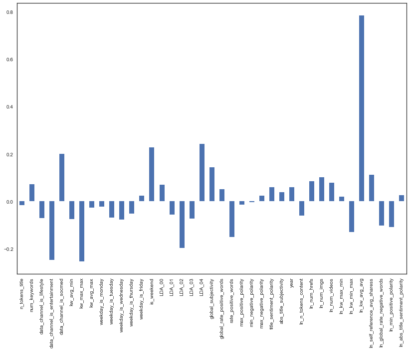

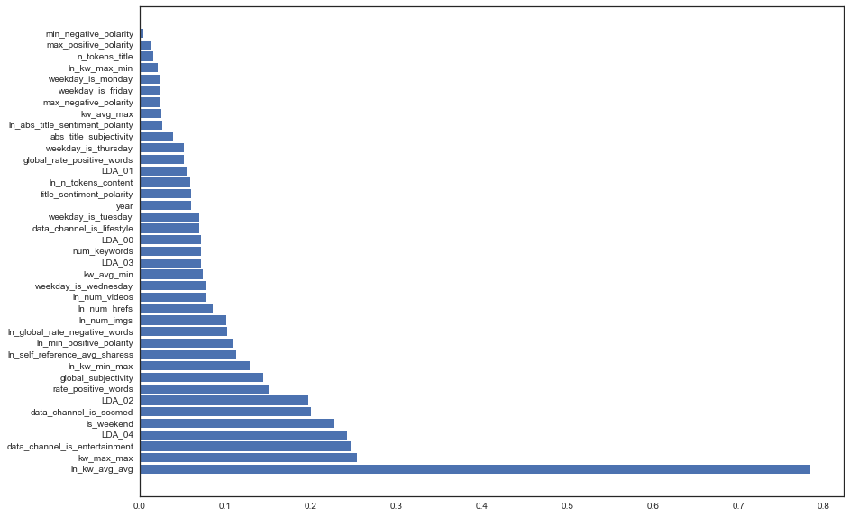

```
                           ln_kw_avg_avg :     0.784
                              kw_max_max :     0.254
           data_channel_is_entertainment :     0.247
                                  LDA_04 :     0.242
                              is_weekend :     0.227
                  data_channel_is_socmed :     0.201
                                  LDA_02 :     0.197
                     rate_positive_words :     0.151
                     global_subjectivity :     0.144
                           ln_kw_min_max :     0.129
           ln_self_reference_avg_sharess :     0.113
                ln_min_positive_polarity :     0.109
           ln_global_rate_negative_words :     0.102
                             ln_num_imgs :     0.101
                            ln_num_hrefs :     0.085
                           ln_num_videos :     0.079
                    weekday_is_wednesday :     0.077
                              kw_avg_min :     0.074
                                  LDA_03 :     0.072
                            num_keywords :     0.072
                                  LDA_00 :     0.071
               data_channel_is_lifestyle :     0.070
                      weekday_is_tuesday :     0.069
                                    year :     0.060
                title_sentiment_polarity :     0.060
                     ln_n_tokens_content :     0.060
                                  LDA_01 :     0.055
              global_rate_positive_words :     0.052
                     weekday_is_thursday :     0.051
                  abs_title_subjectivity :     0.039
         ln_abs_title_sentiment_polarity :     0.026
                              kw_avg_max :     0.025
                   max_negative_polarity :     0.025
                       weekday_is_friday :     0.024
                       weekday_is_monday :     0.023
                           ln_kw_max_min :     0.021
                          n_tokens_title :     0.016
                   max_positive_polarity :     0.014
                   min_negative_polarity :     0.004
```

```python
# ... -=-=-=-=-=-=-=-=-=-=-=-=-=-=-=-=-=-=-=-=-=-=-=-=-=-=-=-=-=-=-=-=-=-=-=-=-=
# ...  support function to create sorted absolute value of SV weights
# ...
# ...  https://stackoverflow.com/questions/41592661/determining-the-most-contributing-features-for-svm-classifier-in-sklearn
# ... -=-=-=-=-=-=-=-=-=-=-=-=-=-=-=-=-=-=-=-=-=-=-=-=-=-=-=-=-=-=-=-=-=-=-=-=-=

def f_importances(coef, names):
    imp = coef
    imp_abs = abs(coef)
    imp, names = zip(*sorted(zip(imp_abs,names), reverse = True))
    plt.figure(figsize = (14,10))
    plt.barh(range(len(names)), imp, align = 'center')
    plt.yticks(range(len(names)), names)
    plt.show()
    for nm, val in zip(names, imp):
        print ("%40s : %9.3f" % (nm, val))

# ... -=-=-=-=-=-=-=-=-=-=-=-=-=-=-=-=-=-=-=-=-=-=-=-=-=-=-=-=-=-=-=-=-=-=-=-=-=
# ...  if kernel = linear -- can plot out the weights to evaluate relative influences
# ... -=-=-=-=-=-=-=-=-=-=-=-=-=-=-=-=-=-=-=-=-=-=-=-=-=-=-=-=-=-=-=-=-=-=-=-=-=

krnl = 'linear'

if krnl == 'linear':
#    print(svm_clf.coef_)
#    print(df_svm.columns)

# ... - vertical bar chart with sign retained to see +/- effects

    weights = pd.Series(svm_clf.coef_[0], index = df_svm_top39.columns)
    plt.figure(figsize=(14,10))
    weights.plot(kind = 'bar')

# ... - horizontal bar chart of abs value in ranked order

    f_importances(svm_clf.coef_[0], df_svm_top39.columns)
```

Let us review those instances chosen as support vectors. Let's look at the support for the vectors and see if they are indicative of anything.

First, grab the rows that were selected as support vectors (these are usually instances that are hard to classify).

```python
# ... -=-=-=-=-=-=-=-=-=-=-=-=-=-=-=-=-=-=-=-=-=-=-=-=-=-=-=-=-=-=-=-=-=-=-=-=-=
# ...  review suport vectors
# ... -=-=-=-=-=-=-=-=-=-=-=-=-=-=-=-=-=-=-=-=-=-=-=-=-=-=-=-=-=-=-=-=-=-=-=-=-=

df_tested_on = df_svm_top39.iloc[train_indices].copy() # saved from above, the indices chosen for training

# now get the support vectors from the trained model

df_support = df_tested_on.iloc[svm_clf.support_,:].copy()

df_support['popular'] = y[svm_clf.support_] # add back in the 'popular' Column to the pandas dataframe
df_svm_top39['popular'] = y # also add it back in for the original data
```

Now lets see the statistics of these attributes

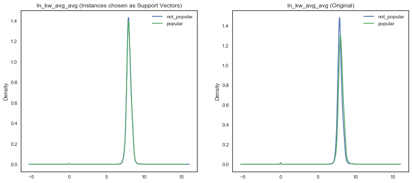

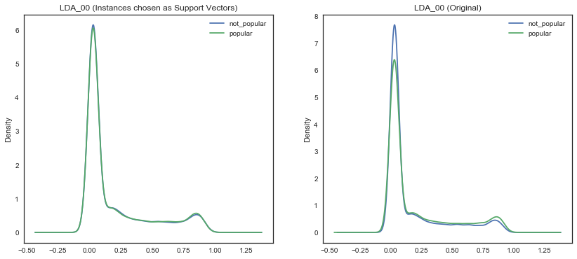

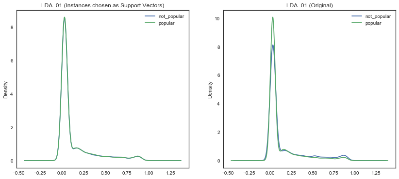

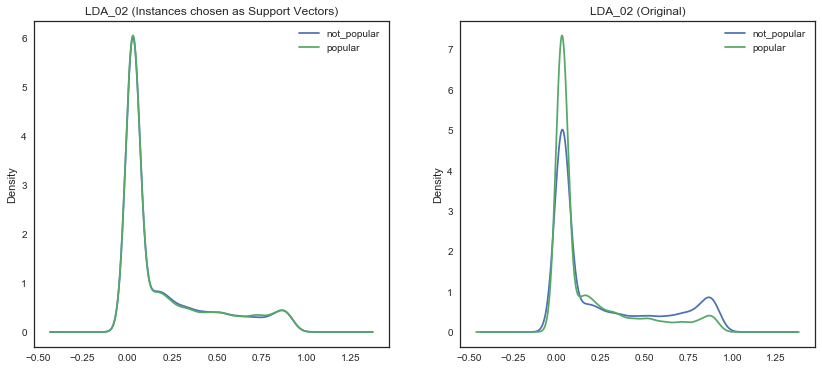

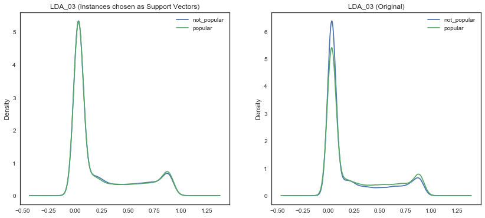

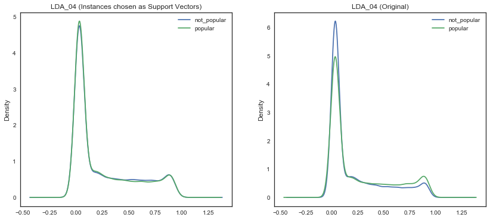

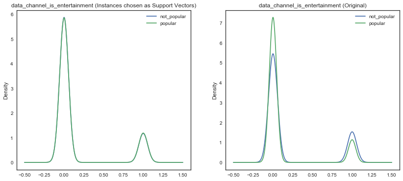

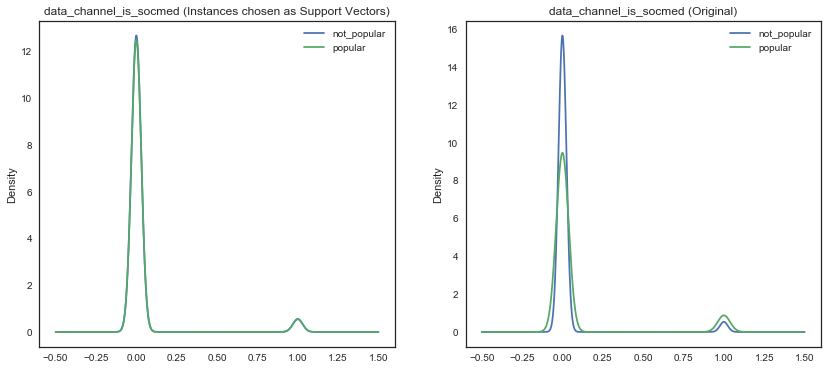

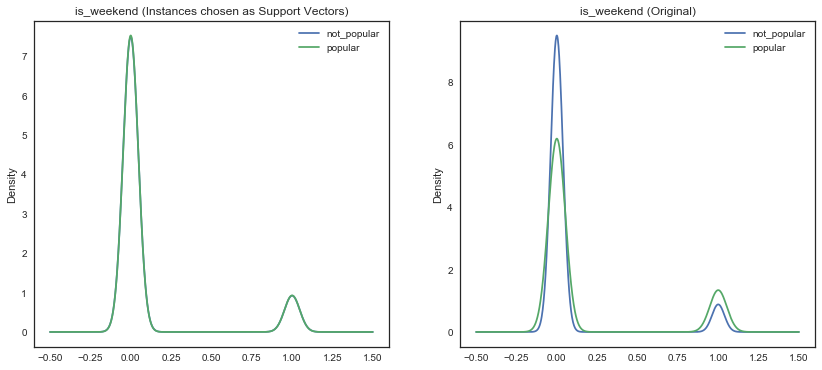

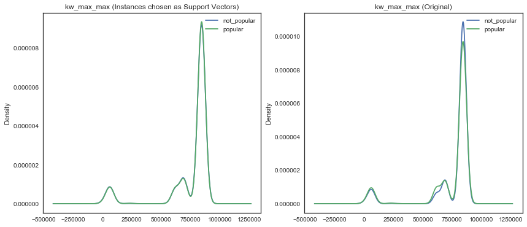

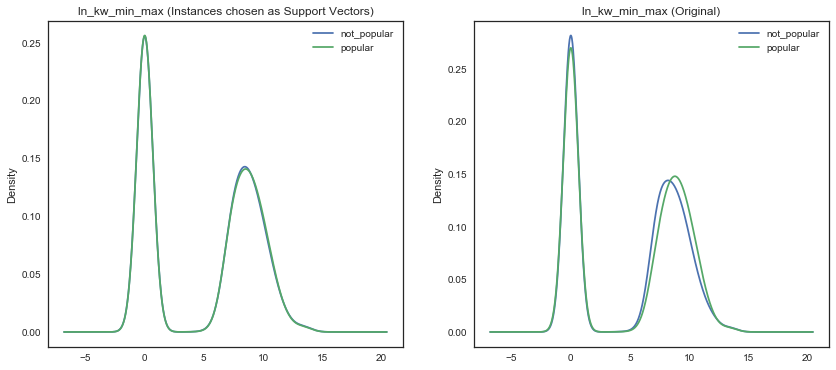

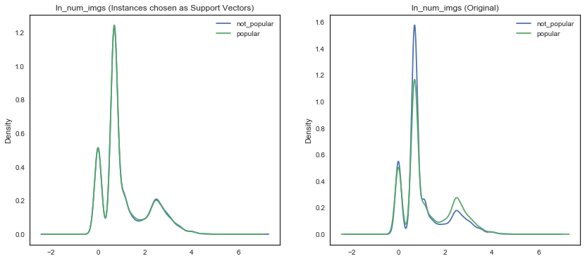

[7 more figures not shown]

```python
from pandas.tools.plotting import boxplot

# group the original data and the support vectors

df_grouped_support = df_support.groupby(['popular'])
df_grouped = df_svm_top39.groupby(['popular'])

# plot KDE of Different variables

vars_to_plot = ['ln_kw_avg_avg',
    'LDA_00',
    'LDA_01',
    'LDA_02',
    'LDA_03',
    'LDA_04',
    'data_channel_is_entertainment',
    'data_channel_is_socmed',
    'is_weekend',
    'kw_max_max',
    'ln_kw_min_max',
    'ln_num_imgs',
    'ln_num_videos',
    'global_subjectivity',
    'rate_positive_words',
    'ln_min_positive_polarity',
    'ln_global_rate_negative_words',
    'ln_self_reference_avg_sharess',
    'num_keywords'
]

for v in vars_to_plot:
    plt.figure(figsize=(14, 6))

    # plot support vector stats

    plt.subplot(1, 2, 1)
    ax = df_grouped_support[v].plot.kde()
    plt.legend(['not_popular','popular'])
    plt.title(v+' (Instances chosen as Support Vectors)')

    # plot original distributions

    plt.subplot(1,2,2)
    ax = df_grouped[v].plot.kde()
    plt.legend(['not_popular','popular'])
    plt.title(v+' (Original)')
```

From Dr Larsen .ipnyb template :

> The analysis here is basically telling us what the original statistics of the data looked like, and also what the statistics of the support vectors looked like. We can see that the separation in distributions is not as great as the separation for the original data. This is because the support vectors tend to be instances on the edge of the class boundaries and also instances that are classified incorrectly in the training data.

(https://github.com/eclarson/DataMiningNotebooks/blob/master/04.%20Logits%20and%20SVM.ipynb)

### Support Vector Machine - Version 2

We decided to also test a Support Vector Machine model using just the top 20 weighted variables from the linear model. We will test these using the linear kernal as well as a non-linear kernal to see if accuracy is improved.

```python
# ... select top20 weighted parameters from linear model
# ... use in non-linear kernal analyses for ?improved? accuracy
# ... first : repeat linear analysis to see if accuracy affected by down-select

cols_2_keep = ['popular',
 'ln_kw_avg_avg',
    'LDA_00',
    'LDA_01',
    'LDA_02',
    'LDA_03',
    'LDA_04',
    'data_channel_is_entertainment',
    'data_channel_is_socmed',
    'is_weekend',
    'kw_max_max',
    'ln_kw_min_max',
    'ln_num_imgs',
    'ln_num_videos',
    'global_subjectivity',
    'rate_positive_words',
    'ln_min_positive_polarity',
    'ln_global_rate_negative_words',
    'ln_self_reference_avg_sharess',
    'num_keywords']

df_svm_top20 = df_svm[cols_2_keep].copy()
```

Again we separate X and y matrices,then convert to numpy matrices by calling 'values' on the pandas data frames they are now simple matrices for compatibility with scikit-learn.

```python
if 'popular' in df_svm_top20:
    y = df_svm_top20['popular'].values         # set 'popular' as dependent
    del df_svm_top20['popular']                # remove from dataset
    X = df_svm_top20.values                    # use everything else for independent EVs
```

The cross validation object is created as earlier.

```python
num_cv_iterations = 3

num_instances = len(y)

cv_object = ShuffleSplit(n_splits = num_cv_iterations,
                         test_size  = 0.2)

print(cv_object)
```

```
ShuffleSplit(n_splits=3, random_state=None, test_size=0.2, train_size=None)
```

The train and test sets are created and scaled as before:

```python
# ... -=-=-=-=-=-=-=-=-=-=-=-=-=-=-=-=-=-=-=-=-=-=-=-=-=-=-=-=-=-=-=-=-=-=-=-=-=
# ...  run through the cross validation loop and set the training and testing
# ...  variable for one single iteration
# ...
# ...  --> this method is memory-user, but easier to follow what is being done
# ... -=-=-=-=-=-=-=-=-=-=-=-=-=-=-=-=-=-=-=-=-=-=-=-=-=-=-=-=-=-=-=-=-=-=-=-=-=

for train_indices, test_indices in cv_object.split(X, y):
    X_train = X[train_indices]
    y_train = y[train_indices]
    X_test = X[test_indices]
    y_test = y[test_indices]

# ... -=-=-=-=-=-=-=-=-=-=-=-=-=-=-=-=-=-=-=-=-=-=-=-=-=-=-=-=-=-=-=-=-=-=-=-=-=
# ... scale attributes by the training set
# ... - normalize features based on mean & stdev of each column
# ... - do not use the testing data
# ... - use what was last stored in the variables: X_train, y_train, X_test, y_test
# ... -=-=-=-=-=-=-=-=-=-=-=-=-=-=-=-=-=-=-=-=-=-=-=-=-=-=-=-=-=-=-=-=-=-=-=-=-=

scl_obj = StandardScaler()
scl_obj.fit(X_train)                        # scale for each column for (0,1) mean, std

X_train_scaled = scl_obj.transform(X_train) # apply to training
X_test_scaled = scl_obj.transform(X_test)
```

This time we will test different combinations of parameters. The results are displayed in a table following the code.

```python
# ... -=-=-=-=-=-=-=-=-=-=-=-=-=-=-=-=-=-=-=-=-=-=-=-=-=-=-=-=-=-=-=-=-=-=-=-=-=
# ... use SVM, train the model
# ...
# ... - C = 0.5
# ...   - penalty parameter; controls the trade-off between smooth decision boundary
# ...   - and classifying the training points correctly
# ...
# ... - kernel = linear
# ...
# ... - gamma = auto
# ...   - kernel coefficient for ‘rbf’, ‘poly’ and ‘sigmoid’;
# ...   - the higher the value of gamma, will try to exact fit
# ...   - for the rbf kernel the transformed space is infinite-dimensional
# ...
# ...  https://www.analyticsvidhya.com/blog/2017/09/understaing-support-vector-machine-example-code/
# ... -=-=-=-=-=-=-=-=-=-=-=-=-=-=-=-=-=-=-=-=-=-=-=-=-=-=-=-=-=-=-=-=-=-=-=-=-=

#C_param = 0.5

for ikrnl in ['linear', 'rbf', 'poly', 'sigmoid']:
    for C_param in [0.5, 1, 2, 4]:
        #C_param = C_param * 2
        tic = time.clock()
        # ...  get SVC object
        krnl = ikrnl
        gamma_param = 'auto'
        svm_clf = SVC(C = C_param, kernel = krnl, degree = 3, gamma = gamma_param)
        # ... train
        svm_clf.fit(X_train_scaled, y_train)
        # ... print out process time
        toc = time.clock()
        print('\n----------------------------------------------------')
        print('Process time : ', toc - tic, 'seconds')
        print('----------------------------------------------------')
        # ... test set predictions
        y_hat = svm_clf.predict(X_test_scaled)
        # ... model classification metrics
        acc = mt.accuracy_score(y_test, y_hat)
        rec = mt.recall_score(y_test, y_hat)
        pre = mt.precision_score(y_test, y_hat)
        f1s = mt.f1_score(y_test, y_hat)
        conf = mt.confusion_matrix(y_test, y_hat)
        print('\n----------------------------------------------------')
        print('Model Accuracy = ', acc )
        print('Model Recall = ', rec )
        print('Model Precision = ', pre )
        print('Model F1 Score = ', f1s )
        print('\n----------------------------------------------------')
        print('Confusion matrix\n', conf)
        print('----------------------------------------------------')
        # ... add model metrics to results data frame
        new_row = [krnl, C_param, gamma_param, len(df_svm_top20.columns), toc-tic, acc, rec, pre, f1s]
        df_results.loc[len(df_results)] = new_row

print(df_results)
```

```
----------------------------------------------------
Process time :  50.73436857024677 seconds
----------------------------------------------------

----------------------------------------------------
Model Accuracy =  0.644469668306
Model Recall =  0.651397515528
Model Precision =  0.630985209326
Model F1 Score =  0.641028906151

----------------------------------------------------
Confusion matrix
 [[2593 1472]
 [1347 2517]]
----------------------------------------------------

----------------------------------------------------
Process time :  67.0943476529979 seconds
----------------------------------------------------

----------------------------------------------------
Model Accuracy =  0.644721906924
Model Recall =  0.651397515528
Model Precision =  0.631301730625
Model F1 Score =  0.641192204815

----------------------------------------------------
Confusion matrix
 [[2595 1470]
 [1347 2517]]
----------------------------------------------------

----------------------------------------------------
Process time :  104.34941396794073 seconds
----------------------------------------------------

----------------------------------------------------
Model Accuracy =  0.644721906924
Model Recall =  0.651397515528
Model Precision =  0.631301730625
```

[output cut: 237 more lines]

```
2    0.631302  0.641192
3    0.631302  0.641192
4    0.631302  0.641192
5    0.642343  0.644662
6    0.644502  0.644585
7    0.649031  0.645144
8    0.651379  0.643531
9    0.653396  0.613187
10   0.653802  0.616416
11   0.652300  0.616036
12   0.651987  0.619481
13   0.536434  0.536850
14   0.534106  0.535553
15   0.536999  0.542638
16   0.532715  0.533953
```

#### The accuracy does not change much with 20 down selected features as above compared with 39 features

This can be seen by comparing lines 0 and 4 in the table above. Of the kernals, RBF appears to be outperforming the others just a bit. The C parameter has the most impact on the time taken to run the model so we will choose 0.5 to reduce cost.

Will will use these parameters and re-run the analysis with 20 features and non-linear kernel  
kernel = **rbf**

```python
# ... -=-=-=-=-=-=-=-=-=-=-=-=-=-=-=-=-=-=-=-=-=-=-=-=-=-=-=-=-=-=-=-=-=-=-=-=-=
# ... use SVM, train the model
# ...
# ... - C = 0.5
# ...   - penalty parameter; controls the trade-off between smooth decision boundary
# ...   - and classifying the training points correctly
# ...
# ... - kernel = rbf
# ...
# ... - gamma = auto
# ...   - kernel coefficient for ‘rbf’, ‘poly’ and ‘sigmoid’;
# ...   - the higher the value of gamma, will try to exact fit
# ...   - for the rbf kernel the transformed space is infinite-dimensional
# ...
# ...  https://www.analyticsvidhya.com/blog/2017/09/understaing-support-vector-machine-example-code/
# ... -=-=-=-=-=-=-=-=-=-=-=-=-=-=-=-=-=-=-=-=-=-=-=-=-=-=-=-=-=-=-=-=-=-=-=-=-=

tic = time.clock()

# ...  get SVC object

krnl = 'rbf'
C_param = 0.5
gamma_param = 'auto'

svm_clf = SVC(C = 0.5, kernel = 'rbf', degree = 3, gamma = 'auto')

# ... train

svm_clf.fit(X_train_scaled, y_train)

# ... print out process time

toc = time.clock()
print('\n----------------------------------------------------')
print('Process time : ', toc - tic, 'seconds')
print('----------------------------------------------------')

# ... test set predictions

y_hat = svm_clf.predict(X_test_scaled)

# ... model classification metrics

acc = mt.accuracy_score(y_test, y_hat)
rec = mt.recall_score(y_test, y_hat)
pre = mt.precision_score(y_test, y_hat)
f1s = mt.f1_score(y_test, y_hat)

conf = mt.confusion_matrix(y_test, y_hat)

print('\n----------------------------------------------------')
print('Model Accuracy = ', acc )
print('Model Recall = ', rec )
print('Model Precision = ', pre )
print('Model F1 Score = ', f1s )

print('\n----------------------------------------------------')
print('Confusion matrix\n', conf)
print('----------------------------------------------------')


# ... add model metrics to results data frame, we don't need to redisplay it just yet.

new_row = [krnl, C_param, gamma_param, len(df_svm_top20.columns), toc-tic, acc, rec, pre, f1s]
df_results.loc[len(df_results)] = new_row
```

```
----------------------------------------------------
Process time :  41.072873999999956 seconds
----------------------------------------------------

----------------------------------------------------
Model Accuracy =  0.652162946147
Model Recall =  0.660199131989
Model Precision =  0.644405681535
Model F1 Score =  0.652206809584

----------------------------------------------------
Confusion matrix
 [[2585 1427]
 [1331 2586]]
----------------------------------------------------
```

We will try the same model with fewer variables to obseve how the accuracy changes.

```python
# ... select Top10 ... and repeat

cols_2_keep = ['popular',
    'ln_kw_avg_avg',
    'kw_max_max',
    'LDA_00',
    'LDA_01',
    'LDA_02',
    'LDA_03',
    'LDA_04',
    'data_channel_is_entertainment',
    'data_channel_is_socmed',
    'is_weekend']

df_svm_top10 = df_svm[cols_2_keep].copy()


if 'popular' in df_svm_top10:
    y = df_svm_top10['popular'].values         # set 'popular' as dependent
    del df_svm_top10['popular']                # remove from dataset
    X = df_svm_top10.values                    # use everything else for independent EVs

num_cv_iterations = 3

num_instances = len(y)

cv_object = ShuffleSplit(n_splits = num_cv_iterations,
                         test_size  = 0.2)

print(cv_object)

for train_indices, test_indices in cv_object.split(X, y):
    X_train = X[train_indices]
    y_train = y[train_indices]
    X_test = X[test_indices]
    y_test = y[test_indices]

    scl_obj = StandardScaler()
    scl_obj.fit(X_train)                        # scale for each column for (0,1) mean, std

    X_train_scaled = scl_obj.transform(X_train) # apply to training
    X_test_scaled = scl_obj.transform(X_test)


tic = time.clock()

# ...  get SVC object

krnl = 'linear'
C_param = 0.5
gamma_param = 'auto'

svm_clf = SVC(C = 0.5, kernel = 'linear', degree = 3, gamma = 'auto')

# ... train

svm_clf.fit(X_train_scaled, y_train)

# ... print out process time

toc = time.clock()
print('\n----------------------------------------------------')
print('Process time : ', toc - tic, 'seconds')
print('----------------------------------------------------')

# ... test set predictions

y_hat = svm_clf.predict(X_test_scaled)

# ... model classification metrics

acc = mt.accuracy_score(y_test, y_hat)
rec = mt.recall_score(y_test, y_hat)
pre = mt.precision_score(y_test, y_hat)
f1s = mt.f1_score(y_test, y_hat)

conf = mt.confusion_matrix(y_test, y_hat)

print('\n----------------------------------------------------')
print('Model Accuracy = ', acc )
print('Model Recall = ', rec )
print('Model Precision = ', pre )
print('Model F1 Score = ', f1s )

print('\n----------------------------------------------------')
print('Confusion matrix\n', conf)
print('----------------------------------------------------')


# ... add model metrics to results data frame

new_row = [krnl, C_param, gamma_param, len(df_svm_top10.columns), toc-tic, acc, rec, pre, f1s]
df_results.loc[len(df_results)] = new_row
```

```
ShuffleSplit(n_splits=3, random_state=None, test_size=0.2, train_size=None)

----------------------------------------------------
Process time :  29.37490042973468 seconds
----------------------------------------------------

----------------------------------------------------
Model Accuracy =  0.623912220961
Model Recall =  0.670126582278
Model Precision =  0.611881645862
Model F1 Score =  0.639681005317

----------------------------------------------------
Confusion matrix
 [[2300 1679]
 [1303 2647]]
----------------------------------------------------
```

The results of all of that are shown in the below table.

```python
print(df_results.round(3))
```

```
     kernel    C gamma n_features  process_time  accuracy  recall  precision  \
0    linear  0.5  auto         39       177.544     0.643   0.645      0.641
1    linear  0.5  auto         19        50.734     0.644   0.651      0.631
2    linear  1.0  auto         19        67.094     0.645   0.651      0.631
3    linear  2.0  auto         19       104.349     0.645   0.651      0.631
4    linear  4.0  auto         19       170.488     0.645   0.651      0.631
5       rbf  0.5  auto         19        52.126     0.652   0.647      0.642
6       rbf  1.0  auto         19        50.691     0.654   0.645      0.645
7       rbf  2.0  auto         19        68.417     0.656   0.641      0.649
8       rbf  4.0  auto         19        80.308     0.657   0.636      0.651
9      poly  0.5  auto         19        41.848     0.645   0.578      0.653
10     poly  1.0  auto         19        44.745     0.646   0.583      0.654
11     poly  2.0  auto         19        60.350     0.645   0.584      0.652
12     poly  4.0  auto         19        76.076     0.647   0.590      0.652
13  sigmoid  0.5  auto         19        62.578     0.548   0.537      0.536
```

[output cut: 24 more lines]

## **Support Vector Interpretation**

From the support vector models, we review the relative weights of the support vectors from the largest model (39 features) to make some obervations about the interpretation of the support vectors.

The relative weights of the highest (top 10, absolute) value weights are as shown in the below Table

| **feature** | **support vector weight** | **LDA_0n correlated to data channel** |
| --- | --- | --- |
| ln_kw_avg_avg | 0.788 |  |
| LDA_02 | 0.585 | World |
| LDA_03 | 0.462 | - none - |
| LDA_01 | 0.337 | Entertainment |
| LDA_00 | 0.299 | Business |
| data_channel_is_entertainment | 0.278 |  |
| kw_max_max | 0.252 |  |
| is_weekend | 0.234 |  |
| data_channel_is_socmed | 0.200 |  |
| LDA_04 | 0.158 | Technology |

We observe that five of the ten features with the highest weights are the *LDA_0n* features. Recall, the *LDA_0n* features are Latent Dirichlet allocation measures associated to the content of the published articles. From the first project submission (https://github.com/bici-sancta/mashable/blob/master/lab_one_submission_2017.09.17/lab_one_mashable_viz_data_processing.html) we observed strong correlations between the *LDS_0n* measures and the article data channels. Those relationships are shown in the above table also.

Based on the KDE plots for the support vectors and population distributions for these features we can understand how these LDA measures and a few other highly weighted explanatory variables relate to popularity / non-popularity.

| **KDE Plots of Selected Feature Support Vectors** | **Interpretation** |
| --- | --- |
|  | LDA_02 ==> Data Channel : World Higher LDA_02 measure is less popular; Mashable readers are less interested in "World" categorized subject matter |
|  | LDA_04 ==> Data Channel : Technology Higher LDA_04 measure is more popular; Mashable readers are more interested in "Technology" categorized subject matter |
|  | is_weekend : *is_weekend* is more popular; Mashable readers perhaps have some more time available on the weekends for reading *mashable* articles !! |
|  | Number of images in the article : *num_images* shows distinct patterns related to number of images published in the article. (The KDE plot is actually ln(num_images + 1) to allow for including article… |

#### **A guideline take-away message for implementation of *mashable* articles with demonstrated success for popularity are the following** :

| **Increase Popularity** | **Decrease Popularity** |
| --- | --- |
| Articles about Business, Technology, Social Media Number of images > 10 Increase use of positive words !! | Articles about World Affairs, Entertainment |

## b.Logistic Regression

For our logistic models we are running 5 models with different parameters.

#### 1. simple logistic without parameters

#### 2. L2 penalty with C value of 0.05

#### 3. L1 penalty with C value of 0.05

#### 4. L2 penalty with C value of 100

#### 5. L1 penalty with C value of 100

Each model will be weighed agaist Accuracy, Precision, Recall, Fscore and Processing Time.

```python
comparison_tbl = pd.DataFrame(columns = ['Model Name','Accuracy','Precision','Recall','FScore','Processing Time'])
from sklearn.linear_model import LogisticRegression
from sklearn.metrics import accuracy_score as acc
from sklearn.metrics import confusion_matrix as conf
from sklearn.metrics import f1_score, precision_score, recall_score, classification_report
from sklearn.metrics import precision_recall_fscore_support as score
from tabulate import tabulate
```

After importing the necessary packages, we first define the Logistic Regression classifiers we will use.

```python
lr_model1 = LogisticRegression()
lr_model2 = LogisticRegression(penalty='l2', C=0.05)
lr_model3 = LogisticRegression(penalty='l1', C=0.05)
lr_model4 = LogisticRegression(penalty='l2', C=100.00)
lr_model5 = LogisticRegression(penalty='l1', C=100.00)
```

```python
if 'popular' in df_svm:
    y = df_svm['popular'].values         # set 'popular' as dependent
    del df_svm['popular']                # remove from dataset
    X = df_svm.values                    # use everything else for independent EVs
```

```python
X.shape
```

```
(39644, 39)
```

```python
num_cv_iterations = 3

num_instances = len(y)

cv_object = ShuffleSplit(n_splits = num_cv_iterations,
                         test_size  = 0.2)

print(cv_object)
```

```
ShuffleSplit(n_splits=3, random_state=None, test_size=0.2, train_size=None)
```

The train and test sets are created and scaled as before:

```python
# ... -=-=-=-=-=-=-=-=-=-=-=-=-=-=-=-=-=-=-=-=-=-=-=-=-=-=-=-=-=-=-=-=-=-=-=-=-=
# ...  run through the cross validation loop and set the training and testing
# ...  variable for one single iteration
# ...
# ...  --> this method is memory-user, but easier to follow what is being done
# ... -=-=-=-=-=-=-=-=-=-=-=-=-=-=-=-=-=-=-=-=-=-=-=-=-=-=-=-=-=-=-=-=-=-=-=-=-=

for train_indices, test_indices in cv_object.split(X, y):
    X_train = X[train_indices]
    y_train = y[train_indices]
    X_test = X[test_indices]
    y_test = y[test_indices]

# ... -=-=-=-=-=-=-=-=-=-=-=-=-=-=-=-=-=-=-=-=-=-=-=-=-=-=-=-=-=-=-=-=-=-=-=-=-=
# ... scale attributes by the training set
# ... - normalize features based on mean & stdev of each column
# ... - do not use the testing data
# ... - use what was last stored in the variables: X_train, y_train, X_test, y_test
# ... -=-=-=-=-=-=-=-=-=-=-=-=-=-=-=-=-=-=-=-=-=-=-=-=-=-=-=-=-=-=-=-=-=-=-=-=-=

scl_obj = StandardScaler()
scl_obj.fit(X_train)                        # scale for each column for (0,1) mean, std

X_train_scaled = scl_obj.transform(X_train) # apply to training
X_test_scaled = scl_obj.transform(X_test)
```

```python
i_index=[]
i_index = 0
# ###################################### LR model 1 ##########################

tic = time.clock()
lr_model1.fit(X_train_scaled, y_train)  # train object
y_hat = lr_model1.predict(X_test_scaled) # get test set precitions
print("====model 1 ====")
accuracy = '{0:.4f}'.format(mt.accuracy_score(y_test, y_hat))
recall = '{0:.4f}'.format(mt.recall_score(y_test, y_hat))
precision = '{0:.4f}'.format(mt.precision_score(y_test, y_hat))
fscore = '{0:.4f}'.format(mt.f1_score(y_test, y_hat))
print("accuracy",accuracy )
print("confusion matrix\n", conf(y_test, y_hat))
print('precision:',precision)
print('recall:',recall)
print('fscore:',fscore)
toc =  time.clock()
exetime = '{0:.4f}'.format(toc-tic)
print('process time',exetime)
print("\n")

raw_data = {
    'Model Name':'LR Model 1, Simple',
    'Accuracy':accuracy,
    'Precision':precision,
    'Recall':recall,
    'FScore':fscore,
    'Processing Time': exetime
}

df = pd.DataFrame(raw_data,columns = ['Model Name','Accuracy','Precision','Recall','FScore','Processing Time'],index=[i_index+1])
comparison_tbl = comparison_tbl.append(df)

# ###################################### LR model 2 ##########################
tic = time.clock()
lr_model2.fit(X_train_scaled, y_train)  # train object
y_hat = lr_model2.predict(X_test_scaled) # get test set precitions

print("====model 2 ====")
accuracy = '{0:.4f}'.format(mt.accuracy_score(y_test, y_hat))
recall = '{0:.4f}'.format(mt.recall_score(y_test, y_hat))
precision = '{0:.4f}'.format(mt.precision_score(y_test, y_hat))
fscore = '{0:.4f}'.format(mt.f1_score(y_test, y_hat))
print("accuracy",accuracy )
print("confusion matrix\n", conf(y_test, y_hat))
print('precision:',precision)
print('recall:',recall)
print('fscore:',fscore)
toc =  time.clock()
exetime = '{0:.4f}'.format(toc-tic)
print('process time',exetime)
print("\n")

raw_data = {
    'Model Name':'LR Model 2,Penalty L2, c 0.05',
    'Accuracy':accuracy,
    'Precision':precision,
    'Recall':recall,
    'FScore':fscore,
    'Processing Time': exetime
}

df = pd.DataFrame(raw_data,columns = ['Model Name','Accuracy','Precision','Recall','FScore','Processing Time'],index=[i_index+1])
comparison_tbl = comparison_tbl.append(df)
# ###################################### LR model 3 ##########################
tic = time.clock()
lr_model3.fit(X_train_scaled, y_train)  # train object
y_hat = lr_model3.predict(X_test_scaled) # get test set precitions

print("====model 3 ====")
accuracy = '{0:.4f}'.format(mt.accuracy_score(y_test, y_hat))
recall = '{0:.4f}'.format(mt.recall_score(y_test, y_hat))
precision = '{0:.4f}'.format(mt.precision_score(y_test, y_hat))
fscore = '{0:.4f}'.format(mt.f1_score(y_test, y_hat))
print("accuracy",accuracy )
print("confusion matrix\n", conf(y_test, y_hat))
print('precision:',precision)
print('recall:',recall)
print('fscore:',fscore)
toc =  time.clock()
exetime = '{0:.4f}'.format(toc-tic)
print('process time',exetime)
print("\n")

raw_data = {
    'Model Name':'LR Model 3,Penalty L1, c 0.05',
    'Accuracy':accuracy,
    'Precision':precision,
    'Recall':recall,
    'FScore':fscore,
    'Processing Time': exetime
}

df = pd.DataFrame(raw_data,columns = ['Model Name','Accuracy','Precision','Recall','FScore','Processing Time'],index=[i_index+1])
comparison_tbl = comparison_tbl.append(df)

# ###################################### LR model 4 ##########################

tic = time.clock()
lr_model4.fit(X_train_scaled, y_train)  # train object
y_hat = lr_model4.predict(X_test_scaled) # get test set precitions

print("====model 4 ====")
accuracy = '{0:.4f}'.format(mt.accuracy_score(y_test, y_hat))
recall = '{0:.4f}'.format(mt.recall_score(y_test, y_hat))
precision = '{0:.4f}'.format(mt.precision_score(y_test, y_hat))
fscore = '{0:.4f}'.format(mt.f1_score(y_test, y_hat))
print("accuracy",accuracy )
print("confusion matrix\n", conf(y_test, y_hat))
print('precision:',precision)
print('recall:',recall)
print('fscore:',fscore)
toc =  time.clock()
exetime = '{0:.4f}'.format(toc-tic)
print('process time',exetime)
print("\n")

raw_data = {
    'Model Name':'LR Model 4,Penalty L1, c 100',
    'Accuracy':accuracy,
    'Precision':precision,
    'Recall':recall,
    'FScore':fscore,
    'Processing Time': exetime
}

df = pd.DataFrame(raw_data,columns = ['Model Name','Accuracy','Precision','Recall','FScore','Processing Time'],index=[i_index+1])
comparison_tbl = comparison_tbl.append(df)

# ################################# LR model 5 #####################

tic = time.clock()
lr_model5.fit(X_train_scaled, y_train)  # train object
y_hat = lr_model5.predict(X_test_scaled) # get test set precitions

print("====model 5 ====")
accuracy = '{0:.4f}'.format(mt.accuracy_score(y_test, y_hat))
recall = '{0:.4f}'.format(mt.recall_score(y_test, y_hat))
precision = '{0:.4f}'.format(mt.precision_score(y_test, y_hat))
fscore = '{0:.4f}'.format(mt.f1_score(y_test, y_hat))
print("accuracy",accuracy )
print("confusion matrix\n", conf(y_test, y_hat))
print('precision:',precision)
print('recall:',recall)
print('fscore:',fscore)
toc =  time.clock()
exetime = '{0:.4f}'.format(toc-tic)
print('process time',exetime)
print("\n")

raw_data = {
    'Model Name':'LR Model 5,Penalty L2, c 100',
    'Accuracy':accuracy,
    'Precision':precision,
    'Recall':recall,
    'FScore':fscore,
    'Processing Time': exetime
}

df = pd.DataFrame(raw_data,columns = ['Model Name','Accuracy','Precision','Recall','FScore','Processing Time'],index=[i_index+1])
comparison_tbl = comparison_tbl.append(df)
```

```
====model 1 ====
accuracy 0.6542
confusion matrix
 [[2660 1298]
 [1444 2527]]
precision: 0.6607
recall: 0.6364
fscore: 0.6483
process time 0.5169


====model 2 ====
accuracy 0.6543
confusion matrix
 [[2661 1297]
 [1444 2527]]
precision: 0.6608
recall: 0.6364
fscore: 0.6484
process time 0.3548


====model 3 ====
accuracy 0.6539
confusion matrix
 [[2652 1306]
 [1438 2533]]
precision: 0.6598
recall: 0.6379
fscore: 0.6487
process time 0.6402


====model 4 ====
accuracy 0.6539
confusion matrix
 [[2659 1299]
 [1445 2526]]
precision: 0.6604
recall: 0.6361
fscore: 0.6480
process time 1.0026


====model 5 ====
accuracy 0.6539
confusion matrix
 [[2659 1299]
 [1445 2526]]
precision: 0.6604
recall: 0.6361
fscore: 0.6480
process time 23.2806
```

# Model Advantages

Let's look at the summary of each model.

```python
#data collation of SVM and LR summary formatting to 4 decimal precision

df_results['Model Name'] = 'SVM '+ df_results['kernel'] +' ,' +df_results['gamma']+' C '+df_results['C'].map(str)+' n '+df_results['n_features'].map(str)
df_results['Precision'] =df_results['precision'].map('{0:.4f}'.format)
df_results['Accuracy']= df_results['accuracy'].map('{0:.4f}'.format)
df_results['FScore']= df_results['f1_score'].map('{0:.4f}'.format)
df_results['Processing Time'] = df_results['process_time'].map('{0:.4f}'.format)
df_results['Recall']= df_results['recall'].map('{0:.4f}'.format)
```

```python
#Remove repeated columns

del df_results['kernel']
del df_results['gamma']
del df_results['C']
del df_results['n_features']
del df_results['precision']
del df_results['accuracy']
del df_results['f1_score']
del df_results['process_time']
del df_results['recall']
```

```python
comparison_tbl = comparison_tbl.append(df_results)
comparison_tbl = comparison_tbl.reset_index(drop=True)
comparison_tbl = comparison_tbl[['Model Name','Accuracy','Precision','Recall','FScore','Processing Time']]
comparison_tbl
```

[output not shown]

For our analysis purpose we will consider 3 scenarios:

1. Best Logistic Regression model
2. Best SVM model
3. Best overall

**2. Best SVM model:** model with kernel adjustments using Radial Basis Function (RBF) , gives slightly higher accuracy compared to other kernel models. We varied 'C' values from 0.5 to 4.0 that did not have significant effect on accuracy or precision, but it increased the processing time.

Our final SVM model would be an RBF with 19 features, we choose model# 12 which has C value of 2.0 from above table.

Let us run a 10 fold crossvalidation of this model to give an idea of how robust is the model.

#### Cross Validation of Logistic Regression model

```python
num_cv_iterations = 10
num_instances = len(y)
cv_object = ShuffleSplit(n_splits = num_cv_iterations,
                         test_size  = 0.2)
cv_accuracy=[]
for iter_num, (train_indices, test_indices) in enumerate(cv_object.split(X,y)):
    X_train = X[train_indices]
    y_train = y[train_indices]

    X_test = X[test_indices]
    y_test = y[test_indices]
    scl_obj = StandardScaler()
    scl_obj.fit(X_train)                        # scale for each column for (0,1) mean, std

    X_train_scaled = scl_obj.transform(X_train) # apply to training
    X_test_scaled = scl_obj.transform(X_test)

    lr_model1.fit(X_train_scaled, y_train)  # train object
    y_hat = lr_model1.predict(X_test_scaled) # get test set precitions
    print("====Iteration",iter_num," ====")
    print("accuracy", acc(y_test, y_hat) )
    print("confusion matrix\n", conf(y_test, y_hat))
    cv_accuracy.append(acc(y_test, y_hat))
    iter_num+=1
```

```
====Iteration 0  ====
accuracy 0.647496531719
confusion matrix
 [[2676 1357]
 [1438 2458]]
====Iteration 1  ====
accuracy 0.650145037205
confusion matrix
 [[2688 1357]
 [1417 2467]]
====Iteration 2  ====
accuracy 0.643208475218
confusion matrix
 [[2682 1384]
 [1445 2418]]
====Iteration 3  ====
accuracy 0.64737041241
confusion matrix
 [[2676 1348]
 [1448 2457]]
====Iteration 4  ====
accuracy 0.646739815866
confusion matrix
 [[2634 1383]
 [1418 2494]]
====Iteration 5  ====
accuracy 0.640812208349
confusion matrix
 [[2587 1395]
 [1453 2494]]
====Iteration 6  ====
accuracy 0.640812208349
confusion matrix
 [[2606 1379]
 [1469 2475]]
====Iteration 7  ====
accuracy 0.654685332324
confusion matrix
 [[2680 1325]
 [1413 2511]]
====Iteration 8  ====
accuracy 0.651153991676
confusion matrix
 [[2652 1275]
 [1491 2511]]
====Iteration 9  ====
accuracy 0.643712952453
confusion matrix
 [[2638 1405]
 [1420 2466]]
```

#### Accurcy plot of Cross validation

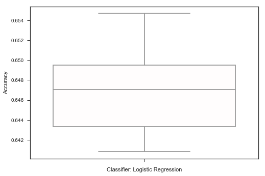

```python
sns.set(style="ticks")
sns.boxplot(y = cv_accuracy,palette="seismic" )
plt.xlabel('Classifier: Logistic Regression')
plt.ylabel('Accuracy')
plt.show()
```

# Interpret feature importance

Our final selected logistic regression model is model 1. Let's look further into the output of model 1.

The features are listed below with the absolute values of their weights. A visual representation follows.

```python
weights = pd.Series(lr_model1.coef_[0], index = df_svm.columns)
weights.sort_values(axis=0, ascending=True, inplace=True)
lr_df = pd.DataFrame(weights).reset_index()
lr_df.columns=['var','weights']
lr_df.weights = lr_df.weights.astype(float)
lr_df.weights = lr_df.weights.abs()
lr_df = lr_df[(lr_df.weights > 0.001) | (lr_df.weights < -0.001)]
lr_df.sort_values(['weights'],ascending=False,inplace=True)
print(tabulate(lr_df,headers=['Variable','Weights'],tablefmt="grid"))
```

```
+----+---------------------------------+------------+
|    | Variable                        |    Weights |
+====+=================================+============+
| 38 | ln_kw_avg_avg                   | 0.532607   |
+----+---------------------------------+------------+
| 37 | is_weekend                      | 0.24137    |
+----+---------------------------------+------------+
|  0 | kw_max_max                      | 0.202907   |
+----+---------------------------------+------------+
| 36 | data_channel_is_socmed          | 0.184162   |
+----+---------------------------------+------------+
|  1 | LDA_02                          | 0.175677   |
+----+---------------------------------+------------+
|  2 | data_channel_is_entertainment   | 0.169866   |
+----+---------------------------------+------------+
| 35 | LDA_04                          | 0.167765   |
+----+---------------------------------+------------+
|  3 | rate_positive_words             | 0.112313   |
+----+---------------------------------+------------+
| 34 | ln_num_imgs                     | 0.107095   |
+----+---------------------------------+------------+
| 33 | LDA_00                          | 0.104898   |
+----+---------------------------------+------------+
| 32 | global_subjectivity             | 0.104864   |
+----+---------------------------------+------------+
| 31 | ln_self_reference_avg_sharess   | 0.0964786  |
+----+---------------------------------+------------+
|  4 | ln_kw_min_max                   | 0.0922913  |
+----+---------------------------------+------------+
|  5 | ln_global_rate_negative_words   | 0.0904442  |
+----+---------------------------------+------------+
|  6 | weekday_is_wednesday            | 0.0792402  |
+----+---------------------------------+------------+
|  7 | ln_n_tokens_content             | 0.0729078  |
+----+---------------------------------+------------+
| 30 | ln_num_hrefs                    | 0.0718065  |
+----+---------------------------------+------------+
|  8 | ln_min_positive_polarity        | 0.070554   |
+----+---------------------------------+------------+
| 29 | ln_num_videos                   | 0.0705063  |
```

[output cut: 26 more lines]

```
+----+---------------------------------+------------+
| 15 | min_negative_polarity           | 0.0304004  |
+----+---------------------------------+------------+
| 16 | kw_avg_max                      | 0.0300187  |
+----+---------------------------------+------------+
| 21 | max_negative_polarity           | 0.0282018  |
+----+---------------------------------+------------+
| 17 | weekday_is_monday               | 0.0270192  |
+----+---------------------------------+------------+
| 20 | weekday_is_friday               | 0.0233957  |
+----+---------------------------------+------------+
| 18 | n_tokens_title                  | 0.0226428  |
+----+---------------------------------+------------+
| 19 | max_positive_polarity           | 0.00803225 |
+----+---------------------------------+------------+
```

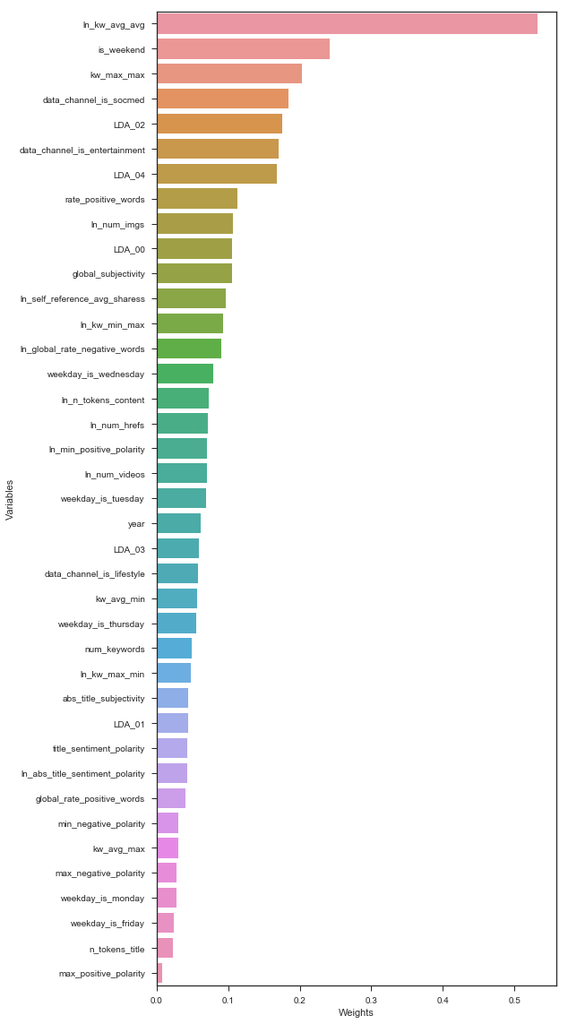

```python
from pylab import rcParams
%matplotlib inline
rcParams['figure.figsize'] = 8, 20
sns.barplot(data=lr_df,y='var',x='weights')
plt.xlabel('Weights')
plt.ylabel('Variables')
plt.show()
```

The most important feature is the **transformed average number of shares of the average keyword** . This makes sense because a higher number of shares from keyword would imply a higher number of overall shares and therefore more popularity.

The second most important feature for determining an article's popularity is if that article is **published on a weekend**. This high weighting also makes sense because a weekend typically has fewer people working and therefore it is reasonable to assume that weekends also have more people browsing social media, where shares take place.

The next few important features are related to the **type of article**, specifically social media or entertainment, and again a keyword derived feature. All of these important features match very well with what intuition would suggest.

The least influential attributes relate to characteristics like day of the week for weekdays, polarity, and the number of words in the title. Again, this weighting agrees with intuition.

Q.E.D